# Actividad 1

Samantha Martinez - A01235915, Antonio Maldonado - A01176753, Natalia Blanco - A01720531

2023-02-07

# Introducción

Concepto neaarshoring

```
 Es un modelo de negocio en el que una empresa subcontrata parte de sus procesos de producción o servicios a una empresa en otro país.
  Beneficios estretegicos :

    - Proximidad geográfica: El nearshoring permite que las empresas tengan una mayor proximidad geográfica con los proveedores y clientes, lo que puede facilitar la comunicación y la colaboración en proyectos y reducir los tiempos de entrega.
    - Costos más bajos: El nearshoring puede ofrecer costos más bajos en comparación con la contratación de proveedores en países lejanos, debido a los costos de transporte y los costos laborales más bajos en ciertos países cercanos.
    - Mayor flexibilidad: El nearshoring puede proporcionar una mayor flexibilidad en la gestión de proyectos, ya que las empresas pueden adaptarse rápidamente a los cambios en los requisitos del proyecto y hacer ajustes en tiempo real debido a la proximidad geográfica y la comunicación efectiva.

En resumen, el nearshoring puede ofrecer beneficios estratégicos a las empresas que buscan reducir costos, mejorar la eficiencia y la calidad de sus procesos de producción y servicios, al mismo tiempo que mantienen una mayor proximidad geográfica y cultural con sus proveedores y clientes.
```

Principales caracteristicas de una base de datos panel

```
Es una estructura de datos en la que se recopilan datos de una misma muestra de individuos o entidades a lo largo del tiempo, por lo general en momentos específicos y con intervalos de tiempo regulares.

  - Observaciones repetidas: Las bases de datos panel se caracterizan por tener múltiples observaciones de una misma muestra de individuos o entidades a lo largo del tiempo. Cada observación se relaciona con una unidad específica, como una persona, una empresa o una región.
  - Variables longitudinales: Las variables de una base de datos panel son longitudinales, es decir, miden una misma variable en distintos momentos en el tiempo. Estas variables pueden ser de distintos tipos, como variables demográficas, económicas o de comportamiento.
  - Estructura de panel: Las bases de datos panel se organizan en una estructura de panel, en la que cada fila representa una unidad de observación, y cada columna representa una variable longitudinal en un momento específico del tiempo.
  - Análisis longitudinal: Las bases de datos panel se utilizan comúnmente en estudios longitudinales, que permiten analizar cómo las variables cambian a lo largo del tiempo para una muestra específica de individuos o entidades.
```

El análisis de datos panel puede contribuir a comprender los factores asociados con el “Nearshoring” para el caso de México.

```
Algunas formas en que el análisis de datos panel puede contribuir a esta comprensión incluyen:

- Identificación de factores clave: A través del análisis de datos panel, se pueden identificar los factores clave que influyen en la decisión de las empresas para elegir México como destino para nearshoring. Estos factores pueden incluir, por ejemplo, la proximidad geográfica a los Estados Unidos, la estabilidad política y económica del país, la disponibilidad de mano de obra calificada y los costos laborales relativamente bajos.
- Análisis de tendencias a lo largo del tiempo: El análisis de datos panel permite analizar cómo los factores asociados con el nearshoring han evolucionado a lo largo del tiempo, lo que puede ayudar a comprender mejor las tendencias en el mercado de nearshoring en México.
- Identificación de patrones y relaciones: El análisis de datos panel puede permitir la identificación de patrones y relaciones entre los factores asociados con el nearshoring.
```

# Importación de datos

```r
# Importar base de datos
library(readxl)
datos <- read_excel("~/Desktop/fid.xlsx")
data <- read_excel("~/Desktop/fid.xlsx")
```

La base de datos cuenta con variables de todos los estados de México, desde el año 2005 al año 2021. Con la variable “new_fdi” = nuevas inversiones en millones de dolares, y variables independientes como salarios diarios, densidad polaciónal, tasa de empleo, tasa de homicidios, tipo de cambio, entre otros.

El siguiente analisis tiene la intención de identificar a base de un modelo de regresión de datos panel, si México atraera inversión extranjera.

```r
library(plm)
# Convertimos base de datos a panel de datos
# Convertir la variable "year" a fecha con formato "año-mes-día"
datos$fecha <- as.Date(paste0(datos$year, "-01-01"), format = "%Y-%m-%d")
# Le indicamos a R que datos es un panel de datos, señalando que state es el criterio para sujetos y year es el criterio de fecha:
datos <- pdata.frame(datos, index= c("state","fecha"))
```

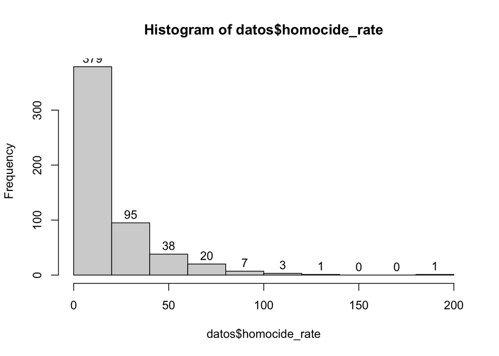

```r
# Todas variables muestran valores atipicos, como se puede ver en este ejemplo, existe una cola larga hacia la derecha. Por lo que sera necesario guardar las variables a utilizar con log.
hist(datos$homocide_rate, labels = TRUE)
```

```r
# Se aplica la funcion de log para suavizar la distribucion de los datos
datos$log.new_fdi = ifelse(datos$new_fdi<=0,0,log(datos$new_fdi))
datos$log.homocide_rate = ifelse(datos$homocide_rate<=0,NA,log(datos$homocide_rate))
datos$log.pop_density = ifelse(datos$pop_density<=0,NA,log(datos$pop_density))
datos$log.border_distance = ifelse(datos$border_distance<=0,NA,log(datos$border_distance))
datos$log.business_activity = ifelse(datos$business_activity<=0,NA,log(datos$business_activity))
```

# Visualización de datos

Desempeño a lo largo del tiempo de las variables de interés

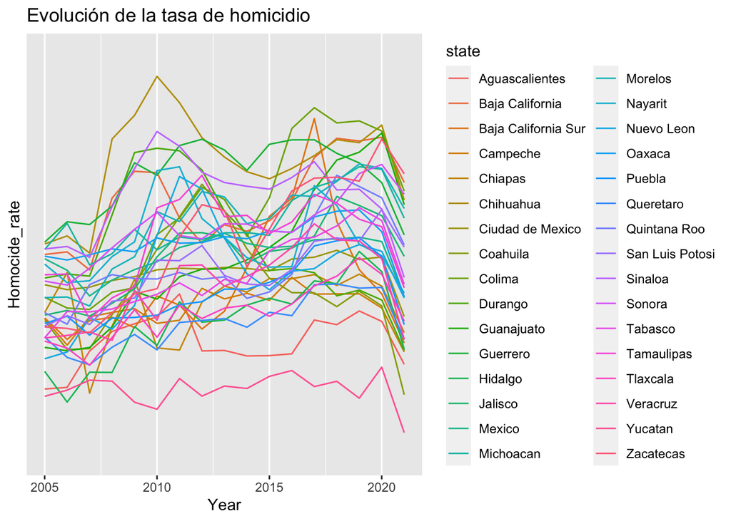

```r
# Visualizacion de la evolucion de la tasa de homicidio por el tiempo
library(ggplot2)
ggplot(datos, aes(x = year, y = log.homocide_rate, group = state, color = state)) +
  geom_line() +
  labs(title = "Evolución de la tasa de homicidio", x = "Year", y = "Homocide_rate")
```

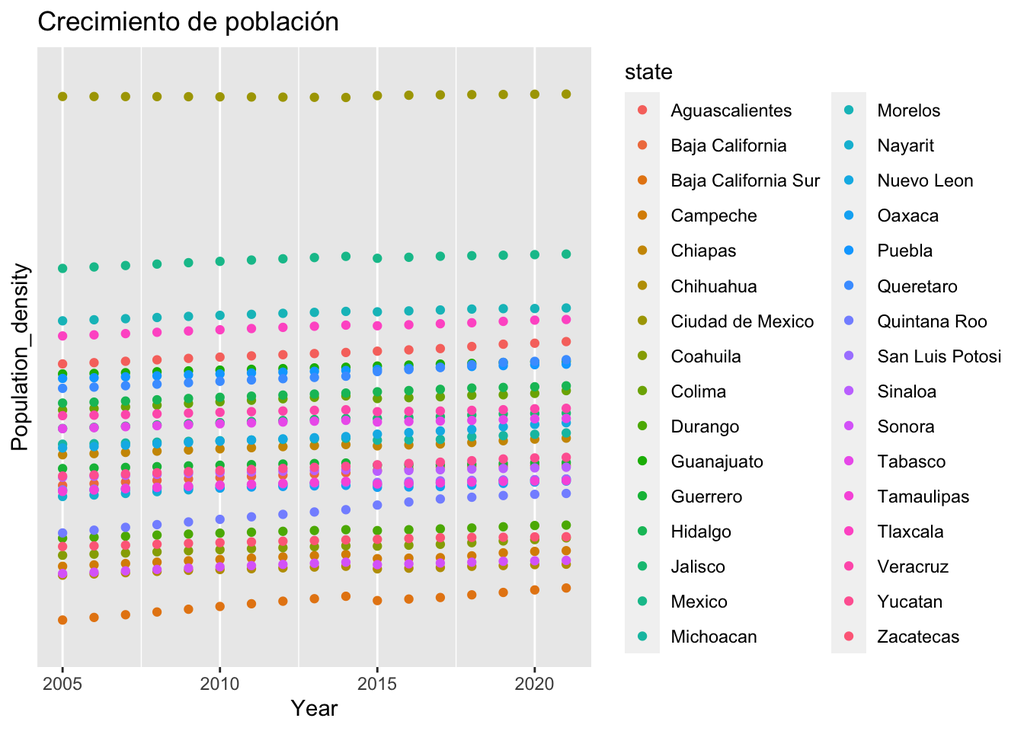

```r
#Visualizacion de el crecimiento de poblacion por tiempo
ggplot(datos, aes(x = year, y = log.pop_density, color = state)) +
  geom_point() +
  labs(title = "Crecimiento de población", x = "Year", y = "Population_density")
```

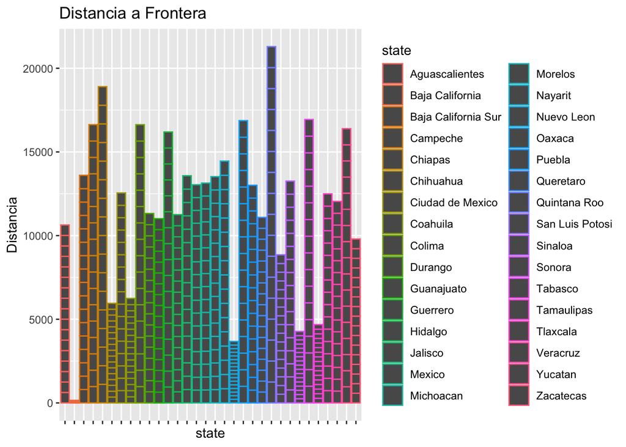

```r
#Visualizacion de distancia a frontera
ggplot(data, aes(x = state, y = border_distance, color = state)) +
  geom_bar(stat = "identity") +
  labs(title = "Distancia a Frontera", y = "Distancia") +
  theme(axis.text.x = element_blank())
```

# Especificación de Modelo de Regresión de Datos Panel

| Variable dependiente | Variables explicativas |
| --- | --- |
| new_fdi | pop_density |
|  | homocide_rate |
|  | business_activity |
|  | border_distance |

# Estimación de Modelo(s) de Regresión de Datos Panel

MODELO : OLS

```r
ols<-lm(new_fdi ~ pop_density + homocide_rate + business_activity + border_distance, data=datos)
summary(ols)
```

```
##
## Call:
## lm(formula = new_fdi ~ pop_density + homocide_rate + business_activity +
##     border_distance, data = datos)
##
## Residuals:
##     Min      1Q  Median      3Q     Max
## -1523.3  -280.1  -131.8    71.0  4150.2
##
## Coefficients:
##                    Estimate Std. Error t value Pr(>|t|)
## (Intercept)       851.26595   77.36825  11.003  < 2e-16 ***
## pop_density        -0.05047    0.02369  -2.131   0.0336 *
## homocide_rate      -1.53797    1.20147  -1.280   0.2011
## business_activity   5.80253    5.59000   1.038   0.2997
## border_distance    -0.63153    0.09068  -6.965 9.63e-12 ***
## ---
## Signif. codes:  0 '***' 0.001 '**' 0.01 '*' 0.05 '.' 0.1 ' ' 1
##
## Residual standard error: 571.9 on 539 degrees of freedom
## Multiple R-squared:  0.09337,    Adjusted R-squared:  0.08665
## F-statistic: 13.88 on 4 and 539 DF,  p-value: 8.8e-11
```

MODELO : FIXED EFFECTS

```r
fixed<-plm(new_fdi ~ pop_density + homocide_rate + business_activity + border_distance, data=datos, model="within", effect = "twoways")
summary(fixed)
```

```
## Twoways effects Within Model
##
## Call:
## plm(formula = new_fdi ~ pop_density + homocide_rate + business_activity +
##     border_distance, data = datos, effect = "twoways", model = "within")
##
## Balanced Panel: n = 32, T = 17, N = 544
##
## Residuals:
##      Min.   1st Qu.    Median   3rd Qu.      Max.
## -3129.112  -141.965   -28.078    99.723  2916.170
##
## Coefficients:
##                   Estimate Std. Error t-value Pr(>|t|)
## pop_density        0.12924    0.99281  0.1302   0.8965
## homocide_rate     -0.50354    1.25107 -0.4025   0.6875
## business_activity  4.29186    4.61733  0.9295   0.3531
##
## Total Sum of Squares:    73400000
## Residual Sum of Squares: 73243000
## R-Squared:      0.0021405
## Adj. R-Squared: -0.099062
## F-statistic: 0.352514 on 3 and 493 DF, p-value: 0.78735
```

```r
# Test de significación para determinar si el modelo de efectos fijos es significativamente mejor que un modelo de regresión lineal ordinario (OLS)
pFtest(fixed, ols)
```

```
##
##  F test for twoways effects
##
## data:  new_fdi ~ pop_density + homocide_rate + business_activity + border_distance
## F = 15.077, df1 = 46, df2 = 493, p-value < 2.2e-16
## alternative hypothesis: significant effects
```

El valor p obtenido es menor que el nivel de significación comúnmente utilizado de 0.05, lo que indica que hay suficiente evidencia para rechazar la hipótesis nula de que el modelo OLS no es significativamente mejor que el modelo de efectos fijos.

MODELO : RANDOM

```r
random<-plm(new_fdi ~ pop_density + homocide_rate + business_activity + border_distance, data=datos, model="random")
summary(random)
```

```
## Oneway (individual) effect Random Effect Model
##    (Swamy-Arora's transformation)
##
## Call:
## plm(formula = new_fdi ~ pop_density + homocide_rate + business_activity +
##     border_distance, data = datos, model = "random")
##
## Balanced Panel: n = 32, T = 17, N = 544
##
## Effects:
##                    var  std.dev share
## idiosyncratic 163245.1    404.0 0.461
## individual    191162.9    437.2 0.539
## theta: 0.7813
##
## Residuals:
##     Min.  1st Qu.   Median  3rd Qu.     Max.
## -2952.77  -151.33   -61.60    44.15  3129.73
##
## Coefficients:
##                     Estimate Std. Error z-value  Pr(>|z|)
## (Intercept)       843.439174 221.439646  3.8089 0.0001396 ***
## pop_density        -0.049745   0.075827 -0.6560 0.5118032
## homocide_rate      -1.115992   1.119391 -0.9970 0.3187820
## business_activity   3.923753   4.056201  0.9673 0.3333707
## border_distance    -0.627570   0.289103 -2.1707 0.0299503 *
## ---
## Signif. codes:  0 '***' 0.001 '**' 0.01 '*' 0.05 '.' 0.1 ' ' 1
##
## Total Sum of Squares:    88735000
## Residual Sum of Squares: 87553000
## R-Squared:      0.01332
## Adj. R-Squared: 0.0059973
## Chisq: 7.27618 on 4 DF, p-value: 0.12199
```

```r
# Test de significación para determinar si el modelo de efectos aleatorios es significativamente mejor que el modelo de efectos fijos.
pFtest(fixed, random)
```

```
##
##  F test for twoways effects
##
## data:  new_fdi ~ pop_density + homocide_rate + business_activity + border_distance
## F = 2.0941, df1 = 46, df2 = 493, p-value = 6.936e-05
## alternative hypothesis: significant effects
```

MODELO : DYNAMIC PANEL MODEL

```r
dynamic<-plm(new_fdi ~ lag(new_fdi,1) + pop_density + homocide_rate + business_activity + border_distance, data=datos, model="within", effect="twoways")
summary(dynamic)
```

```
## Twoways effects Within Model
##
## Call:
## plm(formula = new_fdi ~ lag(new_fdi, 1) + pop_density + homocide_rate +
##     business_activity + border_distance, data = datos, effect = "twoways",
##     model = "within")
##
## Balanced Panel: n = 32, T = 16, N = 512
##
## Residuals:
##      Min.   1st Qu.    Median   3rd Qu.      Max.
## -3069.106  -139.788   -25.387    95.480  3065.533
##
## Coefficients:
##                    Estimate Std. Error t-value Pr(>|t|)
## lag(new_fdi, 1)    0.028905   0.045117  0.6407   0.5221
## pop_density       -0.040304   1.000150 -0.0403   0.9679
## homocide_rate     -0.794410   1.251048 -0.6350   0.5257
## business_activity  3.399623   4.682741  0.7260   0.4682
##
## Total Sum of Squares:    65520000
## Residual Sum of Squares: 65335000
## R-Squared:      0.0028298
## Adj. R-Squared: -0.10532
## F-statistic: 0.327061 on 4 and 461 DF, p-value: 0.85981
```

# Pruebas de Diagnóstico a modelo fixed,random & dynamic

Identificamos la posible presencia de los siguientes problemas en cada uno de los modelos de regresión de datos panel estimados:

1. Heterocedasticidad (heteroscedasticity)
2. Autocorrelación Serial (serial correlation)
3. Estacionariedad (stationary)

### Heterocedasticidad

```r
# Prueba de heterocedasticidad de acuerdo al modelo Breusch-Pegan test.
# El valor de p inferior al 5% indica la presencia de heterocedasticidad.
bptest(fixed)
```

```
##
##  studentized Breusch-Pagan test
##
## data:  fixed
## BP = 30.824, df = 4, p-value = 3.325e-06
```

```r
bptest(random)
```

```
##
##  studentized Breusch-Pagan test
##
## data:  random
## BP = 30.824, df = 4, p-value = 3.325e-06
```

```r
bptest(dynamic)
```

```
##
##  studentized Breusch-Pagan test
##
## data:  dynamic
## BP = 95.979, df = 5, p-value < 2.2e-16
```

Segun el test anterior, los tres modelos cuentan con heterocedasticidad.

### Autocorrelacion serial

```r
# Prueba de autocorrelacion serial segun el test test de Breusch-Godfrey
pbgtest(fixed)
```

```
##
##  Breusch-Godfrey/Wooldridge test for serial correlation in panel models
##
## data:  new_fdi ~ pop_density + homocide_rate + business_activity + border_distance
## chisq = 77.885, df = 17, p-value = 9.085e-10
## alternative hypothesis: serial correlation in idiosyncratic errors
```

```r
pbgtest(random)
```

```
##
##  Breusch-Godfrey/Wooldridge test for serial correlation in panel models
##
## data:  new_fdi ~ pop_density + homocide_rate + business_activity + border_distance
## chisq = 80.22, df = 17, p-value = 3.505e-10
## alternative hypothesis: serial correlation in idiosyncratic errors
```

El valor p es menor que 5%, lo que indica la presencia de correlación serial en los residuos de regresión de panel. Por lo que se rechaza la hipotesis nula. Las nuevas inversiones del pasado estan afectando las nuevas inversiones de hoy.

```r
pbgtest(dynamic)
```

```
##
##  Breusch-Godfrey/Wooldridge test for serial correlation in panel models
##
## data:  new_fdi ~ lag(new_fdi, 1) + pop_density + homocide_rate + business_activity +  ...
## chisq = 82.08, df = 16, p-value = 7.004e-11
## alternative hypothesis: serial correlation in idiosyncratic errors
```

### Estacionariedad

```r
# Prueba de estacionariedad
# Identificamos si existe un proceso estacionario en datos de series de tiempo
adf.test(datos$new_fdi, k=2) # k the lag order to calculate the test statistic.
```

```
##
##  Augmented Dickey-Fuller Test
##
## data:  datos$new_fdi
## Dickey-Fuller = -6.2142, Lag order = 2, p-value = 0.01
## alternative hypothesis: stationary
```

El P-value es menor a 5 por ciento, es estacionaria, lo cual significa que tal vez no sea necesario examinar el modelo en base a diferencias.

```r
# Hagamos que las nuevas inversiones sean consistentes y se arregle heteroscedasticity.
# Identificamos variables significativas
coeftest(fixed, vcovHC)
```

```
##
## t test of coefficients:
##
##                   Estimate Std. Error t value Pr(>|t|)
## pop_density        0.12924    0.31711  0.4075   0.6838
## homocide_rate     -0.50354    1.59188 -0.3163   0.7519
## business_activity  4.29186    3.02814  1.4173   0.1570
```

```r
coeftest(random, vcovHC)
```

```
##
## t test of coefficients:
##
##                     Estimate Std. Error t value Pr(>|t|)
## (Intercept)       843.439174 328.384193  2.5685 0.010484 *
## pop_density        -0.049745   0.017132 -2.9037 0.003839 **
## homocide_rate      -1.115992   1.670091 -0.6682 0.504278
## business_activity   3.923753   3.077896  1.2748 0.202923
## border_distance    -0.627570   0.339738 -1.8472 0.065263 .
## ---
## Signif. codes:  0 '***' 0.001 '**' 0.01 '*' 0.05 '.' 0.1 ' ' 1
```

```r
coeftest(dynamic, vcovHC)
```

```
##
## t test of coefficients:
##
##                    Estimate Std. Error t value Pr(>|t|)
## lag(new_fdi, 1)    0.028905   0.038863  0.7438   0.4574
## pop_density       -0.040304   0.268353 -0.1502   0.8807
## homocide_rate     -0.794410   1.628297 -0.4879   0.6259
## business_activity  3.399623   3.045115  1.1164   0.2648
```

## Comparación de modelos : fixed,random & dynamic

[output not shown]

```
##
## ================================================
##                    fixed    random       dynamic
## ------------------------------------------------
## pop_density          0.13     -0.05       -0.04
##                     (0.99)    (0.08)      (1.00)
## homocide_rate       -0.50     -1.12       -0.79
##                     (1.25)    (1.12)      (1.25)
## business_activity    4.29      3.92        3.40
##                     (4.62)    (4.06)      (4.68)
## (Intercept)                  843.44 ***
##                             (221.44)
## border_distance               -0.63 *
##                               (0.29)
## lag(new_fdi, 1)                            0.03
##                                           (0.05)
## ------------------------------------------------
## R^2                  0.00      0.01        0.00
## Adj. R^2            -0.10      0.01       -0.11
## Num. obs.          544       544         512
## s_idios                      404.04
## s_id                         437.22
## ================================================
## *** p < 0.001; ** p < 0.01; * p < 0.05
```

Se puede observar que le unico modelo con variables explicativas significativas es random.

# Selección de Modelo e Interpretación de Resultados

Al realizar todas las pruebas de diagnóstico y contrarrestar los diferentes modelos analizados, llegamos a la conclusión de que la mejor opción para el modelo es el de random. Esto ocurre porque al momento de realizar la comparación de los tres modelos: Fixed, Random y Dynamic se encontró que el modelo que contenía las variables explicativas significativas era el de random. Al escoger este modelo, nos aseguramos de que estas variables tengan una relación congruente hacia la variable original de respuesta y así validando más los resultados.

# Conclusiones

Después de conducir los diferentes modelos y familiarizarnos con el análisis de datos panel podemos concluir que al momento de conducir análisis de datos panel es necesario tener bien definidas las variables que serán utilizadas. Al hacer nuestros diferentes modelos y análisis notamos las diferencias entre cada prueba de diagnóstico lo cual nos permitió compararlas y finalmente elegir la mejor para nuestro caso. Finalmente el análisis nos permitió entender nuestras variables y cómo estas afectan las tendencias a lo largo del tiempo.